# Aides Drug

Jose Guzman

11/30/2019

# Introduction

A new preventative aides (abacavirinol) is under test in clinical trials. Analyze the effectiveness of this drug across the board. Consider population subgroups by gender, drug use, and sexual orientation. Finish this!

$H_0$ : The drug has no effect on whether one contracts aid or not.

$H_A$ : The drug does not affect susceptibility to aids.

# Methods

For each of these five tests variable analysis, we will use bar graphs and tables to summatrize the data, and chi-squared test for inference.

# Results

does the vaccine help prevent acquiring AIDS in the general populationn? $H_0$ vaccine has no effect $H_A$ vaccine is effective in preventing one from acquiring aids

## Descriptive Results

### Graphical Descriptive Results

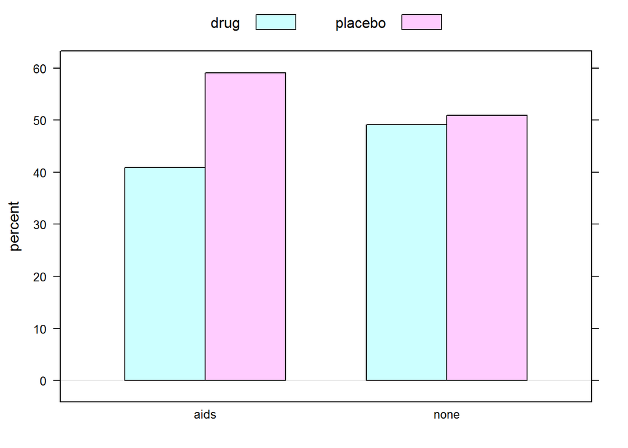

```r
barchartGC(~infected + treatment, type='percent', data=avast)
```

This bar graph shows that the subjects on the drug were less suceptable to contracting aid than those who did not recieve the drug.

### Numerical Descriptive Results

```r
allPeople = xtabs(~infected + treatment)
print(allPeople)
```

```
##         treatment
## infected  drug placebo
##     aids   423     612
##     none 10168   10540
```

This numerical chart shows that the subjects who were on the drug had a lower chance of contracting aid than those who did not.

## Inferential Results

```r
chisqtestGC(allPeople)
```

```
## Pearson's Chi-squared test with Yates' continuity correction
##
## Observed Counts:
##         treatment
## infected  drug placebo
##     aids   423     612
##     none 10168   10540
##
## Counts Expected by Null:
##         treatment
## infected     drug  placebo
##     aids   504.15   530.85
##     none 10086.85 10621.15
##
## Contributions to the chi-square statistic:
##         treatment
## infected  drug placebo
##     aids 13.06   12.40
##     none  0.65    0.62
##
##
## Chi-Square Statistic = 26.4104
## Degrees of Freedom of the table = 1
## P-Value = 0
```

The P- Value for the chisq test is 0 < 0.05 suggests there is a connection between the drug and the subject becoming susceptible to aids.

## Females

# Results

## Descriptive Results

### Graphical Descriptive Results

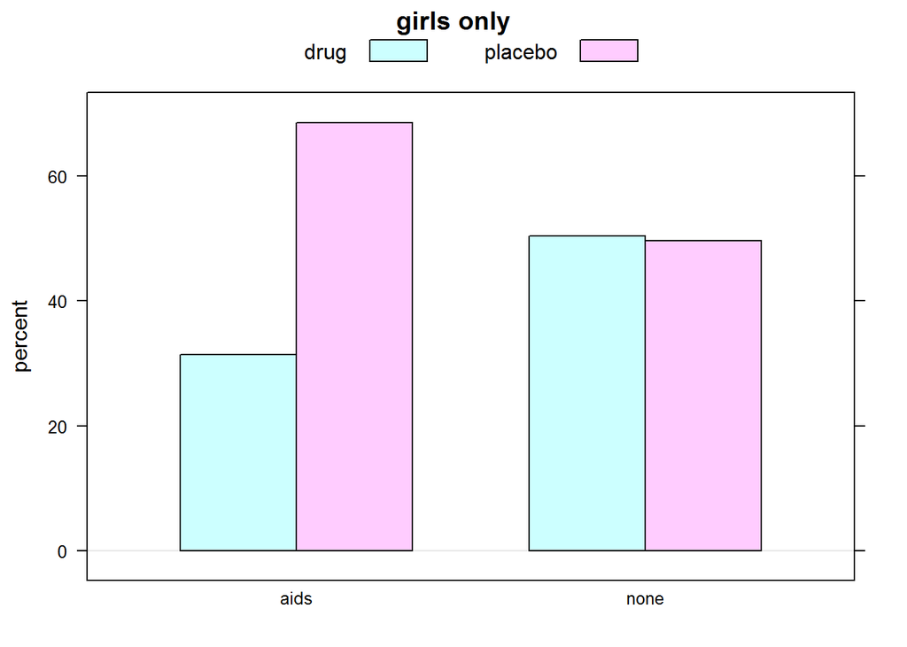

```r
barchartGC(~infected + treatment, type='percent', data=filter(avast, sex =="gal"),main='girls only')
```

this barchart shows that the women who took the drug are less likely to get aids.

### Numerical Descriptive Results

```r
allPeople = xtabs(~infected + treatment, data= filter (avast, sex=="gal"))
print(allPeople)
```

```
##         treatment
## infected drug placebo
##     aids  213     465
##     none 4684    4613
```

This numerica chart shows that the women who were on the drug had a lower chance on contracting aids than those who did not use the drug.

## Inferential Results

```r
chisqtestGC(~infected + treatment,  data=filter(avast, sex =="gal"))
```

```
## Pearson's Chi-squared test with Yates' continuity correction
##
## Observed Counts:
##         treatment
## infected drug placebo
##     aids  213     465
##     none 4684    4613
##
## Counts Expected by Null:
##         treatment
## infected    drug placebo
##     aids  332.85  345.15
##     none 4564.15 4732.85
##
## Contributions to the chi-square statistic:
##         treatment
## infected  drug placebo
##     aids 43.15   41.62
##     none  3.15    3.03
##
##
## Chi-Square Statistic = 90.1943
## Degrees of Freedom of the table = 1
## P-Value = 0
```

The P-value for the chisq test is 0 < 0.05 which suggests there is a connection between the drug and the women on the expierimental drug becoming less susceptible to aids.

## males

# Results

## Descriptive Results

### Graphical Descriptive Results

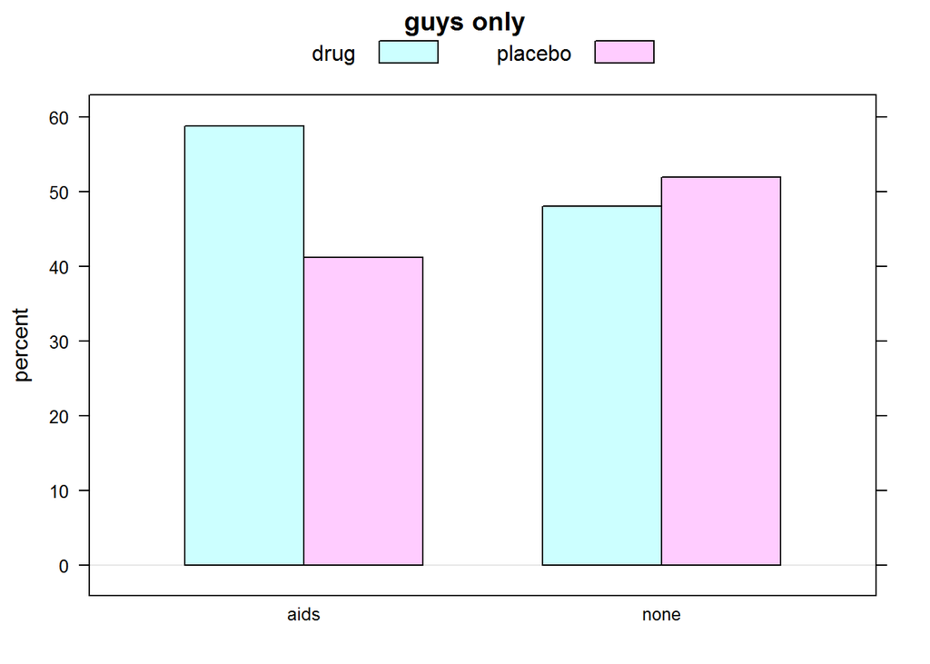

```r
barchartGC(~infected + treatment, type='percent', data=filter(avast, sex =="guy"),main='guys only')
```

This barchart shows that the men who took the drug were more likely to contact aids.

### Numerical Descriptive Results

```r
allPeople = xtabs(~infected + treatment, data= filter (avast, sex=="guy"))
print(allPeople)
```

```
##         treatment
## infected drug placebo
##     aids  210     147
##     none 5484    5927
```

This numerical chart shows that the men who were on the drug had a higher chance of contracting aids than those who didn’t.

## Inferential Results

```r
chisqtestGC(~infected + treatment,  data=filter(avast, sex =="guy"))
```

```
## Pearson's Chi-squared test with Yates' continuity correction
##
## Observed Counts:
##         treatment
## infected drug placebo
##     aids  210     147
##     none 5484    5927
##
## Counts Expected by Null:
##         treatment
## infected    drug placebo
##     aids  172.74  184.26
##     none 5521.26 5889.74
##
## Contributions to the chi-square statistic:
##         treatment
## infected drug placebo
##     aids 8.04    7.54
##     none 0.25    0.24
##
##
## Chi-Square Statistic = 15.6339
## Degrees of Freedom of the table = 1
## P-Value = 1e-04
```

The P-value for this chisq test is 1e-04 <0.05 suggests that there is a connection between the men who take the drug and susceptibiity to aids.

## LGBTQ

# Results

## Descriptive Results

### Graphical Descriptive Results

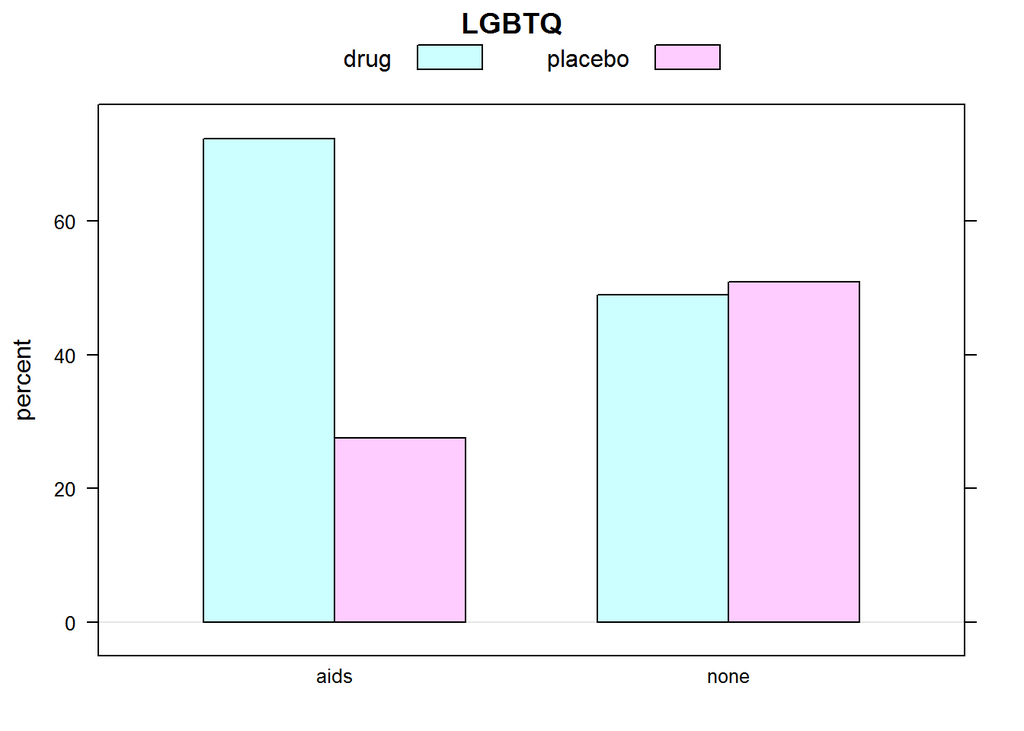

```r
barchartGC(~infected + treatment, type='percent', data=filter(avast, LGBTQ =="gay"),main='LGBTQ')
```

This barchart shows that the drug has an effect on the LGBTQ community and they are more likely to contract aid thn if they got the placebo.

### Numerical Descriptive Results

```r
allPeople = xtabs(~infected + treatment, data= filter (avast, LGBTQ=="gay"))
print(allPeople)
```

```
##         treatment
## infected drug placebo
##     aids   76      29
##     none 1007    1046
```

This numerical chart shows that the LGBTQ community who were on the drug had a higher chance of contracting aid than those who didn’t use the drug.

## Inferential Results

```r
chisqtestGC(~infected + treatment,  data=filter(avast, LGBTQ =="gay"))
```

```
## Pearson's Chi-squared test with Yates' continuity correction
##
## Observed Counts:
##         treatment
## infected drug placebo
##     aids   76      29
##     none 1007    1046
##
## Counts Expected by Null:
##         treatment
## infected    drug placebo
##     aids   52.69   52.31
##     none 1030.31 1022.69
##
## Contributions to the chi-square statistic:
##         treatment
## infected  drug placebo
##     aids 10.31   10.38
##     none  0.53    0.53
##
##
## Chi-Square Statistic = 20.8264
## Degrees of Freedom of the table = 1
## P-Value = 0
```

The P-value for this chisq test was 0 < 0.05 which suggest there is a connection between the drug and the LGBTQ community becoming more susceptible to aids.

The p-value is 0.0 < 0.05

## DrugUsers

# Results

## Descriptive Results

### Graphical Descriptive Results

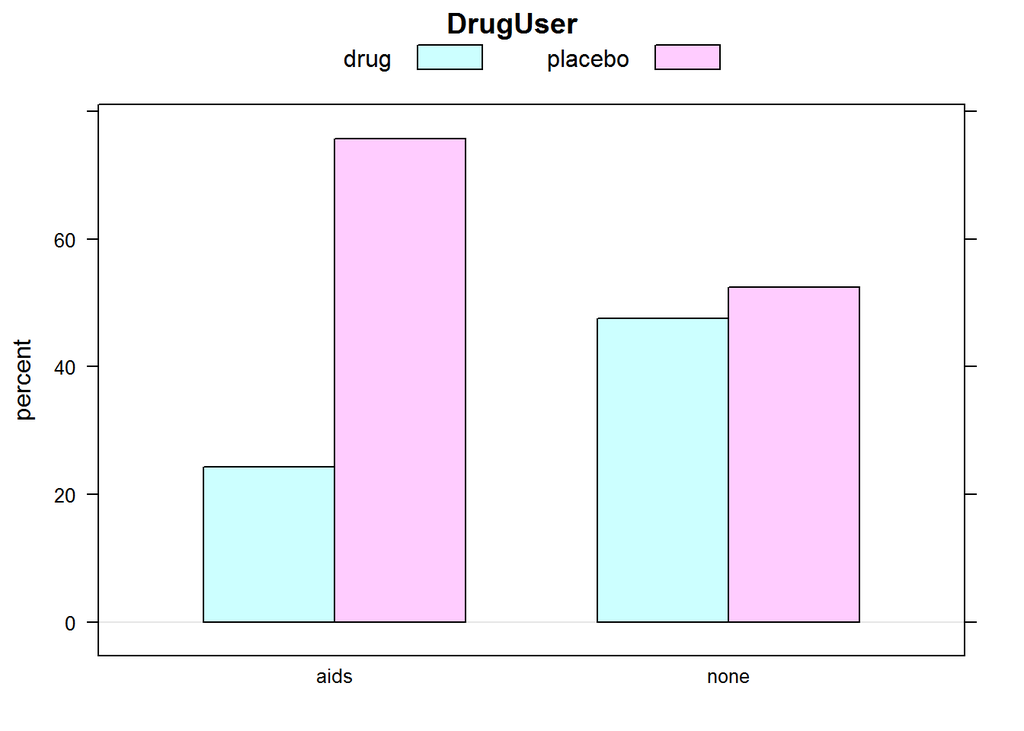

```r
barchartGC(~infected + treatment, type='percent', data=filter(avast,DrugUser=="yes"),main='DrugUser')
```

This barchart shows that the drug does have an effect on drugusers and they are less likely to contract aids than if they got the placebo.

### Numerical Descriptive Results

```r
allPeople = xtabs(~infected + treatment, data= filter (avast, DrugUser=="yes"))
print(allPeople)
```

```
##         treatment
## infected drug placebo
##     aids   34     106
##     none 1143    1259
```

This numerical chart shows that the drug does have an effect on drugusers and they are less likely to contract aid than if they got the placebo.

## Inferential Results

```r
chisqtestGC(~infected + treatment,  data=filter(avast, DrugUser =="yes"))
```

```
## Pearson's Chi-squared test with Yates' continuity correction
##
## Observed Counts:
##         treatment
## infected drug placebo
##     aids   34     106
##     none 1143    1259
##
## Counts Expected by Null:
##         treatment
## infected    drug placebo
##     aids   64.82   75.18
##     none 1112.18 1289.82
##
## Contributions to the chi-square statistic:
##         treatment
## infected  drug placebo
##     aids 14.66   12.64
##     none  0.85    0.74
##
##
## Chi-Square Statistic = 27.955
## Degrees of Freedom of the table = 1
## P-Value = 0
```

This P-value for this chisq was 0 < 0.05 which suggest there is a connection between the drug and drugusers becoming less susceptible to aids.

The p-value is 0.0 < 0.05

# Discussion and Conclusion

$H_0$ : The drug has no effect on whether one contracts aid or not.

$H_A$ : The drug does not affect susceptibility to aids.

We reject the null hypothesis and conclude that we have evidence to support that this drug does reduce the likelyhood of contracting aids.

$H_0$ : The drug has no effect on whether females contracts aid or not.

$H_A$ : The drug does not affect females susceptibility to aids.

We reject the null hypothesis and conclude that we have evidence to support that this drug does reduce the likelyhood in women who are on the drug from contracting aids.

$H_0$ : The drug has no effect on whether males contracts aid or not.

$H_A$ : The drug does not affect males susceptibility to aids.

We reject the null hypothesis and conclude we have enough evidence to support that the drug does have an effect on men who use the drug verses who did not.

$H_0$ : The drug has no effect on whether LGBTQ community contracts aid or not.

$H_A$ : The drug does not affect LGBTQ community susceptibility to aids.

We reject the null hypothesis and conclude we have enough evidence to support that there is a connection in the LGBTQ community with those who are on the drug and their susceptibility to aids.

$H_0$ : The drug has no effect on whether drugusers contracts aid or not.

$H_A$ : The drug does not affect drug users susceptibility to aids.

We reject the null hypothesis and conclude we have enough evidence to support that there is a connection with drugusers with those who are on the drug and their susceptibility to aids.